# Project writeup

Emily

2022-10-29

## Emily’s starter Code

```r
#loading data

NYweath <- data.frame(read.csv("data/NYC_weather_1869_2022.csv"))
#xkablesummary(NYweath)
JFKweath <- data.frame(read.csv("data/JFK_weather_1949-2022.csv"))
#xkablesummary(JFKweath)
```

```r
#loading packages and data

NYweath <- data.frame(read.csv("data/NYC_weather_1869_2022.csv"))
#xkablesummary(NYweath)
#str(NYweath)
#cablehead(NYweath, n=5)
#tail(NYweath, n=2)
#nrow(NYweath)
```

```r
#converting to R date format and adding columns for day, month, and year
NYweath$DATE <- as.Date(NYweath$DATE)
NYweath$day <- format(NYweath$DATE, format="%d")
NYweath$month <- format(NYweath$DATE, format="%m")
NYweath$year <- format(NYweath$DATE, format="%Y")

#converting temperature observations to numerics
NYweath$TMAX <- as.numeric(NYweath$TMAX)
NYweath$TMIN <- as.numeric(NYweath$TMIN)
NYweath$TAVG <- as.numeric(NYweath$TAVG)
NYweath$year <- as.numeric(NYweath$year)

#Making month a factor
NYweath$month <- as.factor(NYweath$month)

#creating a subset of the weather data that are only date- and temperature-related
NYweath_sub <- subset(NYweath, select = c(DATE, day, month, year, TMAX, TMIN, TAVG, PRCP, SNOW))

#creating a subset for 1900 on
NYweath_00 <- subset (NYweath_sub, year > 1899) # subsetting to 20th century and later
xkabledplyhead(NYweath_00)

#creating a subset for 1948 on for comparison with JFK data
NYweath_48 <- subset (NYweath_sub, year > 1947)

#now, same for JFK data

#converting to R date format and adding columns for day, month, and year
JFKweath$DATE <- as.Date(JFKweath$DATE)
JFKweath$day <- format(JFKweath$DATE, format="%d")
JFKweath$month <- format(JFKweath$DATE, format="%m")
JFKweath$year <- format(JFKweath$DATE, format="%Y")

#converting temperature observations to numerics
JFKweath$TMAX <- as.numeric(JFKweath$TMAX)
JFKweath$TMIN <- as.numeric(JFKweath$TMIN)
JFKweath$TAVG <- as.numeric(JFKweath$TAVG)
JFKweath$year <- as.numeric(JFKweath$year)

#Making month a factor
JFKweath$month <- as.factor(JFKweath$month)

#creating a subset of the weather data that are only date- and temperature-related
JFKweath_sub <- subset(JFKweath, select = c(DATE, day, month, year, TMAX, TMIN, TAVG, PRCP, SNOW))
xkablesummary(JFKweath_sub)
```

```r
# Creating columns for MONTHLY averages of TMAX, TMIN, PRCP, and
# SNOW. Adding columns for MONTHLY totals of PRCP and SNOW.

month_tmax_avg <- aggregate(TMAX ~ month + year, NYweath, mean)
month_tmin_avg <- aggregate(TMIN ~ month + year, NYweath, mean)

month_precip_avg <- aggregate(PRCP ~ month + year, NYweath, mean)
colnames(month_precip_avg)[3] <- "PRCP_AVG"

month_precip_total <- aggregate(PRCP ~ month + year, NYweath, sum)
colnames(month_precip_total)[3] <- "PRCP_TOT"

month_snow_avg <- aggregate(SNOW ~ month + year, NYweath, mean)
colnames(month_snow_avg)[3] <- "SNOW_AVG"

month_snow_total <- aggregate(SNOW ~ month + year, NYweath, sum)
colnames(month_snow_total)[3] <- "SNOT_TOT"


monthly_weather <- data.frame(month_tmax_avg,
                              month_tmin_avg$TMIN,
                              month_precip_avg$PRCP_AVG,
                              month_precip_total$PRCP_TOT,
                              month_snow_avg$SNOW_AVG,
                              month_snow_total$SNOT_TOT)
colnames(monthly_weather)[4:8] <- c("TMIN", "PRCP_AVG", "PRCP_TOT", "SNOW_AVG", "SNOW_TOT")

monthly_weather_100yr <- subset(monthly_weather, monthly_weather$year > 1899 & monthly_weather$year < 2022)
```

```r
# Doing the same for YEARLY data
# Creating columns for YEARLY averages of TMAX, TMIN, PRCP, and
# SNOW. Adding columns for YEARLY totals of PRCP and SNOW.

year_tmax_avg <- aggregate(TMAX ~ year, NYweath, mean)
year_tmin_avg <- aggregate(TMIN ~ year, NYweath, mean)

year_precip_avg <- aggregate(PRCP ~ year, NYweath, mean)
colnames(year_precip_avg)[2] <- "PRCP_AVG"

year_precip_total <- aggregate(PRCP ~ year, NYweath, sum)
colnames(year_precip_total)[2] <- "PRCP_TOT"

year_snow_avg <- aggregate(SNOW ~ year, NYweath, mean)
colnames(year_snow_avg)[2] <- "SNOW_AVG"

year_snow_total <- aggregate(SNOW ~ year, NYweath, sum)
colnames(year_snow_total)[2] <- "SNOT_TOT"


yearly_weather <- data.frame(year_tmax_avg,
                             year_tmin_avg$TMIN,
                             year_precip_avg$PRCP_AVG,
                             year_precip_total$PRCP_TOT,
                             year_snow_avg$SNOW_AVG,
                             year_snow_total$SNOT_TOT)
colnames(yearly_weather)[3:7] <- c("TMIN", "PRCP_AVG", "PRCP_TOT", "SNOW_AVG", "SNOW_TOT")


yearly_weather_100yr <- subset(yearly_weather, yearly_weather$year > 1899 & yearly_weather$year < 2022)
```

As scientists, our team is curious about how humans can affect the natural environment. We wondered if weather conditions in a highly populated region might correlate with notable human activities on a global or local scale.

There is a variety of literature available on global climate change, suggesting that the Earth’s surface temperature is increasing, on average, over time in a way that threatens many lifeforms on our planet. This warming is primarily due to human activity: the combustion of fossil fuels resulting in the emission of carbon dioxide into the atmosphere. We decided to consider local weather trends in a specific urban area to see what we might learn.

After some search, we discovered that historical daily weather records from locations around the United States are made publicly availably by the National Oceanic and Atmospheric Administrative via their website: https://www.ncdc.noaa.gov/cdo-web. We found that a data station in the middle of Central Park in New York City has made more than 56,000 daily weather observations dating back to 1869. The variables observed included daily maximum temperature in degrees Fahrenheit (TMAX), daily minimum temperature in degrees Fahrenheit (TMIN), and daily precipitation (PRCP) and snowfall (SNOW) in inches. We decided to analyze these data to see what trends we might uncover. Our data span the days from February 28, 1869, to September 26, 2022.

Temperature data from Central Park have been studied in the past, and warming trends were observed; we wanted to see what we might discover on our own, from analysis of the original data.

## Our Research Questions

Given that Central Park is an oasis in the middle of a city environment, we wondered whether any weather trends correlate with major human activities– both globally and locally. To explore these possibilities, we formulated the following preliminary questions:

1. Are there statistically measurable changes in weather patterns (e.g., temperature and precipitation levels) over time in New York City?
2. Do temperature trends in New York City align with the documented rise in average global temperatures over the last century?
3. Are there any notable (and statistically significant) changes in weather patterns after/during the pandemic lockdown (perhaps due to changes in commuting patterns)?

To dig in, we began with temperature.

## Emily’s linear model Linear Models of Temperature over Time

We then created a linear model of TMAX vs. year to understand the temperature trends since 1900. The fit parameters were statistically significant, and suggested that both the maximum and minimum daily temperatures in New York’s Central Park have increased on average over time at a rate of approximately 0.026 degrees per year. While the p-value for this parameter is < 2e-16 (well below the threshold of alpha = 0.05), this overall fit is poor, with an adjusted r-squared value of 0.00245.

```r
# Linear regression of TMAX \~ year from 1900 on.
maxTfit00_0 <- lm(formula = TMAX ~ year, data = NYweath_00 )
summary(maxTfit00_0)
```

The poor fit is likely due to the wide range of daily temperatures that occur in a given year as a result of seasonal variation. The following plot of daily maximum temperatures shows the wide variance of the data around the linear model.

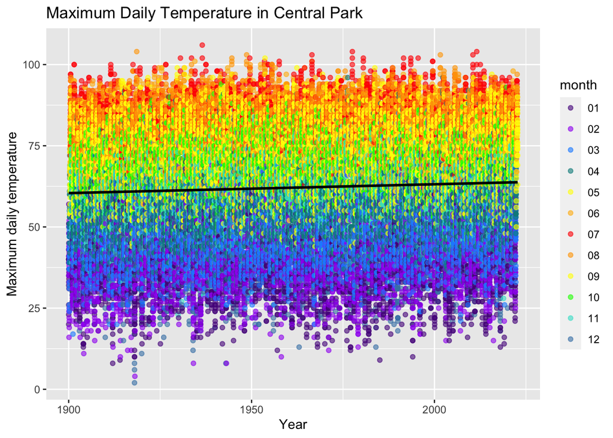

```r
ggplot(NYweath_00, aes(x = DATE, y = TMAX, color = month)) +
    geom_point(alpha = 0.6) +
    scale_color_manual(values = c("01" = "purple4",
                                  "02" = "purple",
                                  "03" = "dodgerblue",
                                  "04" = "cyan4",
                                  "05" = "yellow",
                                  "06" = "darkgoldenrod1",
                                  "07" = "red",
                                  "08" = "orange",
                                  "09" = "yellow",
                                  "10" = "green",
                                  "11" = "turquoise",
                                  "12" = "steelblue")) +
      labs(
        x = "Year",
        y = "Maximum Daily Temperature",
        title = "Maximum Daily Temperature in Central Park") +
    xlab(label = "Year") +
    ylab(label = "Maximum daily temperature") +
    ggtitle(label = "Maximum Daily Temperature in Central Park") +
    stat_smooth(method = "lm",
            formula = y ~ x,
            geom = "smooth",
            color = "black",
            show.legend = F)
```

```r
# Linear regression of TMAX \~ year from 1900 on.
maxTfit00_0 <- lm(formula = TMIN ~ year, data = NYweath_00 )
summary(maxTfit00_0)
```

In order to improve the fit and model temperature trends more completely, we decided to account for seasonal variation by also including month as a categorical regressor. The resulting fit has an r-squared value of 0.775 and a slope of 0.025 degrees Fahreinheit per year, with all fit parameters’ p-values well below 0.05. The different intercepts for the each level of the categorical variable (the twelve months of the year) indicate that January is the coldest and July the hottest month in Central Park, with an average difference in maximum daily temperature of approximately 46 degrees Fahrenheit in any given year over this window.

```r
maxTfit00_1 <- lm(formula = TMAX ~ year + month, data = NYweath_00 )
summary(maxTfit00_1)
```

These two extremes and their linear models are plotted in the following figure; it is clear that the multiple regression is a much better model of temperature trends, consistent with the higher r-squared value.

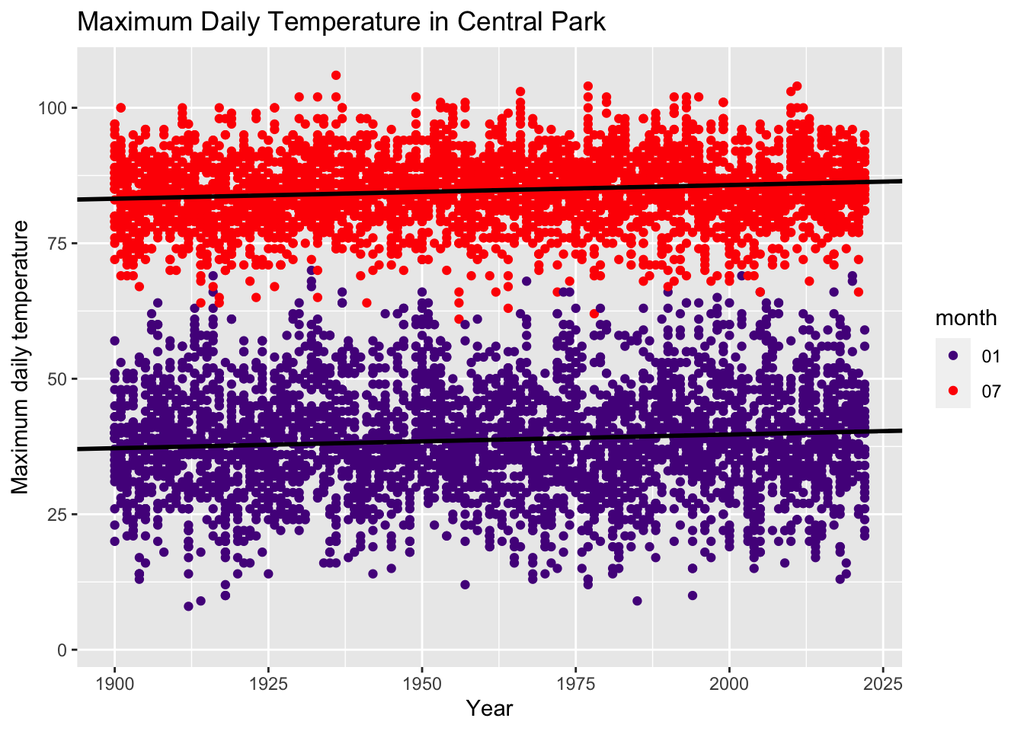

```r
ggplot(NYweath_00, aes(x = year, y = TMAX, color = month)) +
    geom_point() +
    scale_color_manual(values = c("01" = "purple4",
                                   "07" = "red"), na.value = NA) +
    geom_abline(aes(intercept = -11.05508, slope = 0.02539), col = "black", size = 1) +
    geom_abline(aes(intercept = 34.98295, slope = 0.02539), col = "black", size = 1) +

    labs(
        x = "Year",
        y = "Maximum Daily Temperature",
        title = "Maximum Daily Temperature in Central Park") +
    xlab(label = "Year") +
    ylab(label = "Maximum daily temperature") +
    ggtitle(label = "Maximum Daily Temperature in Central Park")
```

```r
#    stat_smooth(method = "lm",
#            formula = y ~ x,
#            geom = "smooth",
#            color = "black",
#            show.legend = F)
```

To create an even better model, we’d need to use sinusoidal functions that capture the cyclical variation of weather with season.

## JFK data, comparable? - Emily

We wondered whether these trends were true for other locations in the New York City area. To assess this, we found data from another NOAA station at JFK International Airport. Because these data date only as far back as the Airport (which was built in 1948), we focused on 1948 on, computing linear models for both regions for this time window.

## Linear models of precipitation trends over time - Chris

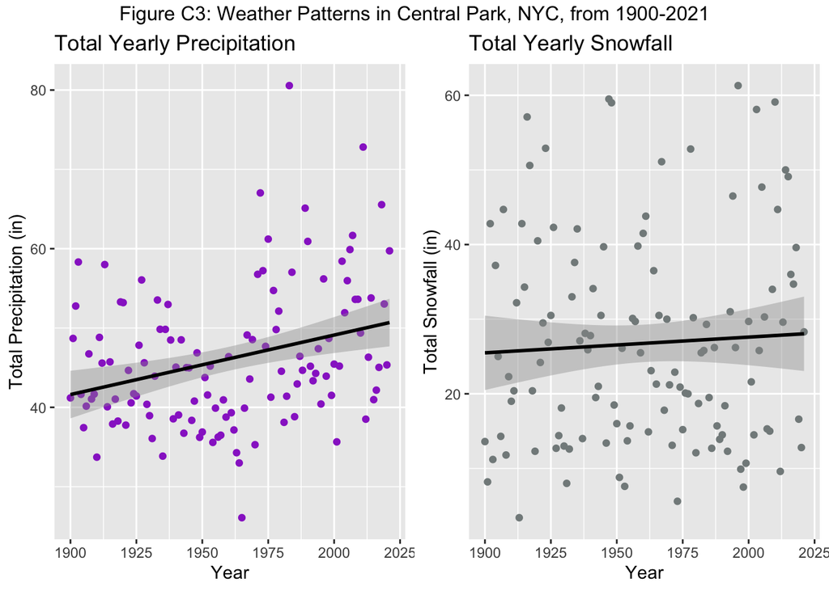

```r
# PRCP linear models and plots
yearly_prcp_scatter <- ggplot(yearly_weather_100yr, aes(x = year, y = PRCP_TOT)) +
  geom_point(color = "darkorchid") +
  labs(x = "Year", y = "Total Precipitation (in)", title = "Total Yearly Precipitation")


lm_prcp_yr <- lm(PRCP_TOT ~ year, data = yearly_weather_100yr)



yearly_snow_scatter <- ggplot(yearly_weather_100yr, aes(x = year, y = SNOW_TOT)) +
  geom_point(color = "azure4") +
  labs(x = "Year", y = "Total Snowfall (in)", title = "Total Yearly Snowfall")

lm_snow_yr <- lm(SNOW_TOT ~ year, data = yearly_weather_100yr)
summary(lm_snow_yr)


yr_prcp_scatter_line <- yearly_prcp_scatter+
  stat_smooth(method = "lm",
              formula = y ~ x,
              geom = "smooth",
              color = "black",
              show.legend = F) +
  labs(title = "Total Yearly Precipitation")


yr_snow_scatter_line <- yearly_snow_scatter+
  stat_smooth(method = "lm",
              formula = y ~ x,
              geom = "smooth",
              color = "black",
              show.legend = F)+
  labs(title = "Total Yearly Snowfall")


grid.arrange(yr_prcp_scatter_line, yr_snow_scatter_line,
             nrow = 1,
             top = "Figure C3: Weather Patterns in Central Park, NYC, from 1900-2021")
```

For total yearly snowfall in Central Park since 1900, there was no statistically significant trend observed in the data.

## Lockdown - Chris

The COVID-19 lockdown had major social, economic, and political impacts in 2020. The lockdown in New York City in Spring of 2020 was one of the earliest in effect and saw unprecedented traffic and life-pattern changes to those who visited and worked in NYC daily.

An analysis was performed to determine if these changes had any affects on the local weather for the city. To do this, the average daily maximum temperatures for spring (considered April and May) and summer (considered June, July and August) were compared using the years leading up to the pandemic and the months following the lockdown order (Figure C4).

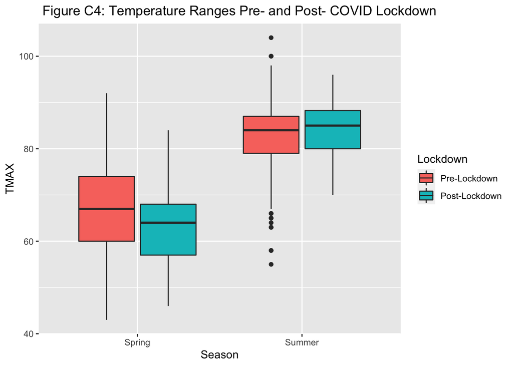

```r
# Generating a lock down box plot
covid_spring_summer <- subset(NYweath,
                           year > 2010 &
                           year <= 2020 &
                          (month == "04" |month == "05" |
                             month == "06" | month == "07" |
                             month == "08"))
covid_spring_summer_ld <- covid_spring_summer %>%
  add_column(Lockdown =
               ifelse(.$year < 2020, "Pre-Lockdown", "Post-Lockdown"),
             .after = "year")
covid_spring_summer_ld$Lockdown <- factor(covid_spring_summer_ld$Lockdown, levels = c('Pre-Lockdown', 'Post-Lockdown'))

covid_ld_season <- covid_spring_summer_ld %>%
  add_column(Season =
               ifelse(.$month == "04" | .$month == "05",
                      "Spring", "Summer"),
             .after = "year")

covid_boxplot <- ggplot()+
  geom_boxplot(data = covid_ld_season, aes(y = TMAX, x = Season, fill = Lockdown)) +
  labs(title = " Figure C4: Temperature Ranges Pre- and Post- COVID Lockdown")

covid_boxplot
```

```r
# performing pre- and post- lock down t test
pre_spring <- subset(NYweath,
                           year > 2010 & year < 2020 &
                           (month == "04" |month == "05"))


pre_summer <- subset(NYweath,
                           year > 2010 & year < 2020 &
                           (month == "06" |month == "07" |
                            month == "08"))


covid_lockdown_spring <- subset(NYweath,
                           year == 2020 &
                           (month == "04" |month == "05"))


covid_lockdown_summer <- subset(NYweath,
                           year == 2020 &
                           (month == "06" |month == "07" |
                            month == "08"))

library(reshape2)

cov_spring_ttest <- t.test(pre_spring$TMAX, covid_lockdown_spring$TMAX)
cov_spring_ttest

cov_summer_ttest <- t.test(pre_summer$TMAX, covid_lockdown_summer$TMAX)
cov_summer_ttest
cov_spring_ttest$conf.int

t.test(pre_spring$TMAX)
t.test(covid_lockdown_spring$TMAX)
```

The spring lockdown months showed a statistically significant difference in the means pre- and post- lockdown order.The post-lockdown months were significantly cooler than the years preceding the COVID-19 pandemic.